# Nationality Difference Lady

Ermakov Pavel

07/5/2020

## Важный дисклеймер

Данная статья не несёт политической, националистской пропаганды. Поэтому её не стоит даже и искать. Разве что в разделе “Дискуссия” я слегка затронул философские темы и немного психологии. Здесь же статистика, направленная на решение одного класса проблем. Также я сам не идеально знаю статистику и грамматику русского языка, поэтому если вы видите ошибку, можете мне написать, исправлю, поблагодарю и добавлю в соавторы (если хотите).

### Ronald Fisher:

> We have the duty of formulating, of summarizing, and of communicating our conclusions, in intelligible form, in recognition of the right of other free minds to utilize them in making their own decisions.

*Рональд Фишер о разделе “Результаты”*

## Введение

Идея для небольшого исследования возникла случайно в процессе разговора, и она была вдохновлена одним из отцом статистики - Рональдом Фишером (именно inferential statistics, она про обобщение результатов с выборок на генеральную совокупность). Он же провёл замечательный эксперимент в 1930-х по тестированию способности леди определять, что было налито первым в кружку: чай или молоко. [Английская статья на вики](https://en.wikipedia.org/wiki/Lady_tasting_tea). Новаторство в дизайне эксперимента заключалось в том, что Фишер стал использовать понятие нулевой гипотезы. И статистический анализ направлен на проверку достоверности этой гипотезы. Он не употреблял понятие альтернативной гипотезы, но её отсутствие не мешает проверять нулевую гипотезу. Результат анализа показал вероятность того, что леди определила бы все кружки правильно случайным образом - 1.4% (маловероятно), а это и есть p-value. А так как она справилась с заданием корректно, поэтому можно было сделать вывод, что леди могла отличать два типа чая на уровне значимости 95%.  
В моём случае леди рассказала, что вполне может различать национальность человека на примере русской и украинской. Таким образом, нам надо проверить, а может ли она правда их отличать.  
В качестве нулевой гипотезы мы берём предположение, что леди не умеет определять эти национальности. Другими словами, действия леди нельзя отличить от действий случайного агента (представляем обезьянку, которая с вероятностями 0.5 и 0.5 нажимает на две кнопки. И далее буду употреблять словосочение “случайный агент”), либо её действия ещё хуже случайного агента. В качестве альтернативной гипотезы мы берём предположение, что леди может различать национальности лучше, чем случайный агент. Можно сразу отметить, что альтернативная гипотеза - односторонняя. Её результат не просто отличается от результата случайного агента, а он именно превосходит.

## Сбор данных

Как по мне, это самый спорный раздел моего исследования. Ведь для хороших данных надо находить людей с генами, характерными именно для данной местности. Вариантов немного: анализировать у респондентов ДНК или родословную. Так как сбор данных спонсируется только моим энтузиазмом, то такое не могу себе позволить. Выбрал менее затратный вариант: искать малые города или деревни по онлайн картам, по названию находить репортажи, любые съёмки на youtube. Далее убеждаться, что человек свободно говорит на языке и имеет характерную для региона фамилию. Брал именно маленькие города, так как полагаю, что там меньше развита международная миграция. Метод не идеальный, зато вполне доступный. Россиян брал в основном на юге, так как в южных городах меньше снежных дней. И находил маленькие поселения на всех российских широтах.  
Повторюсь, результат этого исследования может дать ложный результат, если я действительно обозначал жителей неверно. Но вы понимаете, какие у меня были ограничения. Раздел “Результаты” я писал, предполагая, что данные были собраны верно.

## Теория

Да, важно прочитать, чтобы лучше понимать последующую информацию.

- p-value позволяет нам оценивать достоверность гипотез и их отвергать. Строгое определение - это вероятность получить такое или более экстремальное значение статистики при справедливости нулевой гипотезы. Вероятность менее 5%? Если да, тогда можем отвергать нулевую гипотезу в пользу альтернативной.
- Биномиальное распределение. Это дискретное распределение случайной величины. Параметры - вероятность успеха, количество испытаний. При большом количестве испытаний хорошо аппроксимируется нормальным распределением.
- Доверительные интервалы. Позволяют оценить, в какой доле выборок будет содержаться определённое значение статистики. Сразу на примере: если 95% доверительный интервал для возраста студентов одного университета равен (17, 25), то это значит, что среди большого количества таких же случайных выборок только в 5% случаях среднее значение возраста будет лежать за пределами этого интервала. Для биномиального биномиального можно применять метод нормальной аппроксимации. То есть рассматривать биномиальное распределение как нормальное. Как вы увидите, их форма действительно схожа. Одно из общепринятых правил для такой аппроксимации: $n * p > 5$ и $n * (1-p) > 5$. В нашем случае оба неравенства соблюдаются.
- 60% равняется 0.6, к примеру, и так далее.

## Статистика и методы

Общее количество комбинаций равняется двойке в степени 27. Так как на каждом варианте у человека всего 2 варианта выбора. Далее эти комбинации перемножаются 27 раз.

```r
2 ** 27
```

```
## [1] 134217728
```

И, соответственно, вероятность угадать случайным образом всех 27 человек правильно крайне малая, это обратное число.

```r
1 / (2 ** 27)
```

```
## [1] 7.450581e-09
```

Если продолжать, то вероятность угадать правильно случайным образом 26 и более человек будет количеством комбинаций 27 по 26, поделённым на общее количество комбинаций, плюс предыдущая вероятность.

```r
27 / (2 ** 27) + 1 / (2 ** 27)
```

```
## [1] 2.086163e-07
```

И аналогичным образом мы можем построить все вероятности. Это и будет биномиальное распределение. Посмотрите, какое оно красивое.

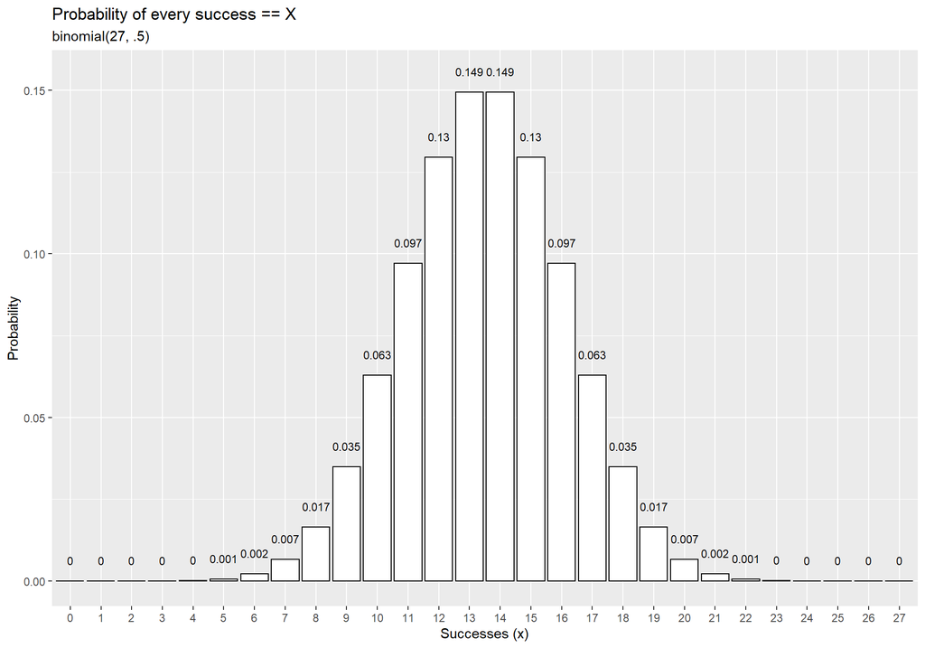

Сухим языком, это биномиальное распределение с вероятностью успеха == 0.5 и количеством испытаний == 27. Так как всего 28 исходов: от 0 угадываний до 27, то наиболее вероятными исходами для случайного агента являются 13 и 14 успехов. Вероятности экстремальных значений не равны нулю, но при округлении до 3 знака после запятой округляются в ноль.  
Для наглядности и примера скажу, что вероятность 10 - 17 успехов равняется 87.8%. Можно сказать, что 87.8% доверительный интервал для успехов - это (10, 17). Если переводить в пропорции, тогда это (37%, 63%). Но мы же используем 95% доверительный интервал.

Важно понять, куда приложить p-value, как его найти. Спокойно, читатель, мы к нему подойдём постепенно и безболезненно.  
Вспоминаем, что p-value - это вероятность получить такое же значение статистики или более высокое при справедливости нулевой гипотезы. Логика такая: если это значение низкое, то мы можем отвергать нулевую гипотезу. Ведь согласно нулевой гипотезе вероятность такого наблюдения крайне редкая, но на практике мы получили такое наблюдение. И далее такому наблюдению приписываются свойства альтернативной гипотезы.  
К примеру, в нашем эксперименте мы получили 15 успехов. Насколько вероятно данное событие при справедливости нулевой гипотезы (леди == случайный агент)? Из определения мы должны сложить вероятности для 15 успехов и далее (до 27).

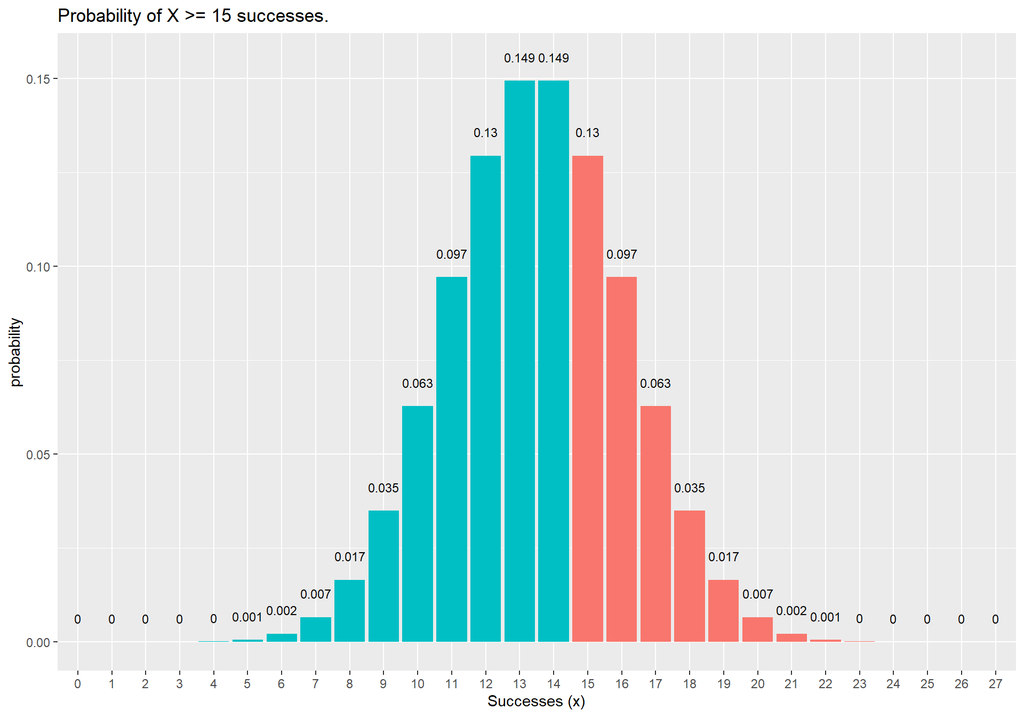

И эта вероятность равняется 0.35.

```
## [1] 0.350554
```

То есть нет ничего удивительного, что человек угадал 15 человек из 27. Оставляем предположение, что человек == случайный агент.

Но если леди угадает 20 человек из 27, тогда вероятность этого будет…

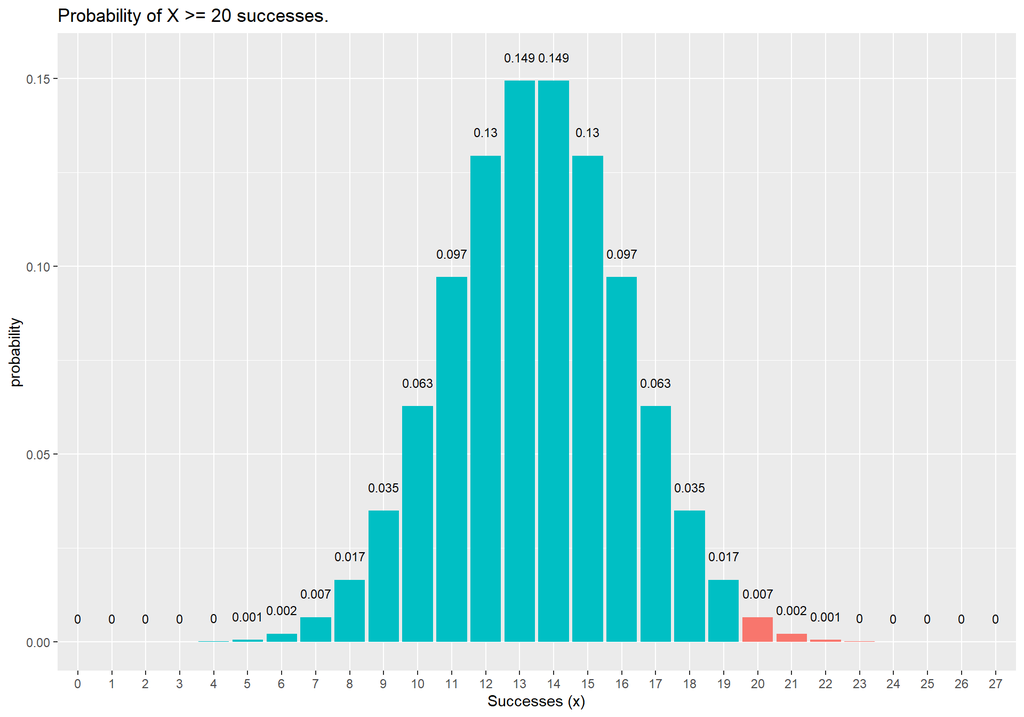

```
## [1] 0.009578645
```

Менее 1%. А это значит, что появление такого значения при нулевой гипотезе маловероятно (< 5% как мы условились при дизайне эксперимента). И мы вправе отвергать нулевую гипотезу в пользу альтернативной: леди умеет определять национальность людей по фотографии.

А теперь давайте найдём пограничное значение успехов, при котором мы будем отвергать нулевую гипотезу.

[figure not shown]

[figure not shown]

```
##
##  1-sample proportions test without continuity correction
##
## data:  17 out of 27, null probability 0.5
## X-squared = 1.8148, df = 1, p-value = 0.08897
## alternative hypothesis: true p is greater than 0.5
## 95 percent confidence interval:
##  0.4716089 1.0000000
## sample estimates:
##         p
## 0.6296296
```

```
##
##  1-sample proportions test without continuity correction
##
## data:  18 out of 27, null probability 0.5
## X-squared = 3, df = 1, p-value = 0.04163
## alternative hypothesis: true p is greater than 0.5
## 95 percent confidence interval:
##  0.508413 1.000000
## sample estimates:
##         p
## 0.6666667
```

В первом мы замечаем, что p-value больше 0.05, и 95% доверительный интервал заходит за 0.5 в отличие от второго теста. Интересно, хотя пропорция успехов равняется 63% в первом случае, мы не в праве отвергнуть нулевую гипотезу при 95% уровне значимости.

Так как группы несколько неравномерны (13 и 14 людей в каждой группе), то можно сомневаться, что случайный агент при выборе действительно будет угадывать ровно половину. Можно убедиться при помощи симуляции сотни тысяч значений, что случайный выбор приводит к биномиальному успеху (0.5) несмотря на сильно неравномерные группы (единиц больше в 99 раз, чем нулей). К такому же выводу можно прийти, просто оценивания математические ожидания.

```
## 0.49948
```

## Результаты

Леди смогла верно определить 11 человек из 27. Так как доля верных ответов меньше 0.5, то здесь и не может идти речи об отвержении нулевой гипотезы. Также участие принял джентельмен, его результат был 12 из 27. Аналогичная ситуация. Оставляем нулевую гипотезу о том, что леди не способна отличать национальности (русскую и украинскую) по фотографиям.  
Вспоминая цитату Рональда Фишера, хочется добавить немного другую формулировку полученных результатов, ведь леди всё же отметила правильно 11 человек из 27. Но нулевая гипотеза нам говорит: результат леди вполне закономерный для случайного агента. Её действия - случайны.

## Дискуссия

Рене Декарт:

> Dubito, ergo cogito, ergo sum (“I doubt, therefore I think, therefore I am”)

В качестве продолжения можно предложить оценивать не просто фотографии, а анимации людей без звука. Они более информативны как-никак. Также более тщательно отбирать людей для классификации. А именно так, что бы они являлись коренными жителями своей местности.

Интересно сопоставить предпосылку эксперимента с когнитивными искажениями. [Красивая диаграмма на вики](https://upload.wikimedia.org/wikipedia/commons/a/a4/The_Cognitive_Bias_Codex_-_180%2B_biases%2C_designed_by_John_Manoogian_III_%28jm3%29.png)  
Данное искажение связано с обилием вокруг нас информации. Так как нет реальной необходимости воспринимать всю информацию, наше внимание действует как фильтр входящей информации. Представьте, вы считаете, что учиться на “отлично” в университете вовсе не обязательно (или любое другое убеждение). А наш мозг не любит пересматривать убеждения, это затратно энергетически и не очень приятно. Поэтому после автоматической фильтрации информации вы получаете только подтверждения своему убеждению. И мы можем долгое время только и думать, что на оценки всё равно никто не смотрит, а на стипендию они не влияют. Так вполне можно думать, но если мы находим только подтверждения своим убеждениям, наше восприятие мира может оказаться замыленным своими же убеждениями. На английском языке, это, скорее всего, [*Confirmation bias*](https://en.wikipedia.org/wiki/Confirmation_bias).  
Люди, верящие в плоскую планету, не обязательно глупы. Скорее, они несколько ленивы для того, чтобы подключить свой рациональный мозг (Система 2 по Канеману) для поиска информации о своём убеждении (а информации очень много).

Поэтому по возможности намекни другому, если считаешь нужным, что сомневаться - это полезно. Куда будет больней впоследствии жалеть о потраченных возможностях, чем немного посомневаться в своих убеждениях прямо сейчас.

Говоря более глобально, война происходит тоже из-за столкновения интересов влиятельных людей. Но за войной стоят человеческие судьбы. Это большая цена для человеческих ошибок. Самое грустное, что всегда была возможность избежать этих ошибок.  
*Руководствовалась когда-либо нападающая сторона рациональными мотивами?*  
*Будет ли 21 век концом сражений за свою правду, за свою веру?*  
**Спасибо за внимание**